# DA101 - Final Project

Yen Nguyen, Hanh Nguyen

2023-04-26

# Data Preparation

## Data Cleaning

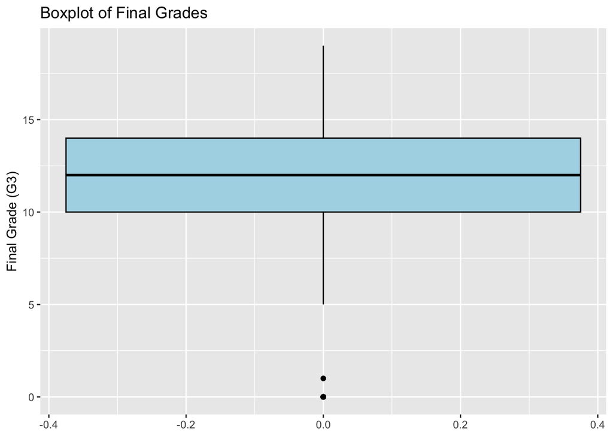

```r
studentData <- read.csv("student-por.csv")

ggplot(data = studentData, aes(y = G3)) +
  geom_boxplot(color = "black", fill = "lightblue") +
  labs(y = "Final Grade (G3)") +
  ggtitle("Boxplot of Final Grades")
```

The boxplot shows there are some outliers in the grades. Therefore, we have to remove the outliers which are those with grades lower than 5 to make the distribution normal and improve the accuracy of finding the factors affecting the final grades.

```r
#remove outliers
studentData <- studentData %>% filter(G3 >= 5)
```

# Data Wrangling

Since there are a small number of students whose parents do not live together and the dataset does not provide information on whether they live with their mother or father, we have decided to focus our analysis on students whose parents’ cohabitation status is “together” (Pstatus = T). This subset of data is likely to provide more accurate and meaningful insights into the factors affecting student performance. This subset of data comprises approximately 90% of the students in the dataset.

```r
studentData <- studentData %>% select("sex", "Walc" , "Dalc", "Pstatus", "Medu", "Fedu", "G3")
studentData <- studentData %>% filter(Pstatus == "T")
```

# Data Exploration

## Heatmap

We will use a heatmap to explore the relationship between different factors and their impact on final grades in our dataset. This visualization will provide us with a clear overview of the correlation between the variables and help us identify any strong positive or negative relationships between them.

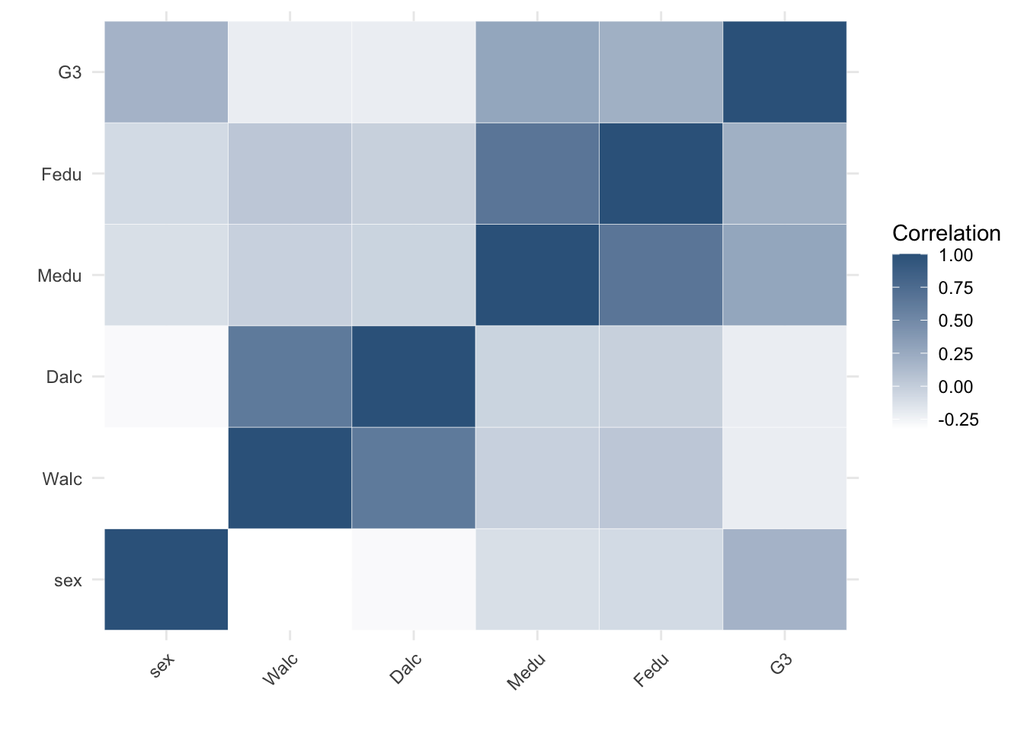

```r
# Convert 'sex' to numeric (F = 1, M = 0)
studentData$sex <- ifelse(studentData$sex == "M", 0, 1)
# Compute the correlation matrix
correlation_matrix <- cor(studentData[c("sex", "Walc" , "Dalc", "Medu", "Fedu", "G3")])

# Convert the correlation matrix into a dataframe
correlation_df <- as.data.frame(as.table(correlation_matrix))

# Rename columns
colnames(correlation_df) <- c("Var1", "Var2", "Correlation")

# Create the heatmap
ggplot(correlation_df, aes(x = Var1, y = Var2, fill = Correlation)) +
  geom_tile(color = "white") +
  scale_fill_gradient(low = "white", high = "steelblue4") +
  theme_minimal() +
  labs(x = "", y = "") +
  theme(axis.text.x = element_text(angle = 45, hjust = 1),
        legend.position = "right")
```

## Adding new variables

The parental education composite variable (“parent_edu”) and the weekly alcohol consumption composite variable (“alc”) are calculated using the following formulas:

$alc = \frac{(Walc \times 2 + Dalc \times 5)}{7}$

$\text{parent_edu} = \frac{(Medu + Fedu)}{2}$

```r
studentData <- studentData %>% mutate(alc = ceiling((Walc*2 + Dalc*5)/7))
studentData <- studentData %>% mutate(parent_edu = ceiling((Medu + Fedu)/2))
```

## Boxplots

We will generate boxplots to visualize the distribution of final grades (G3) across different levels of parental education and alcohol consumption. This allows us to compare the distributions of final grades between groups and identify any potential relationships or patterns between the variables in our dataset.

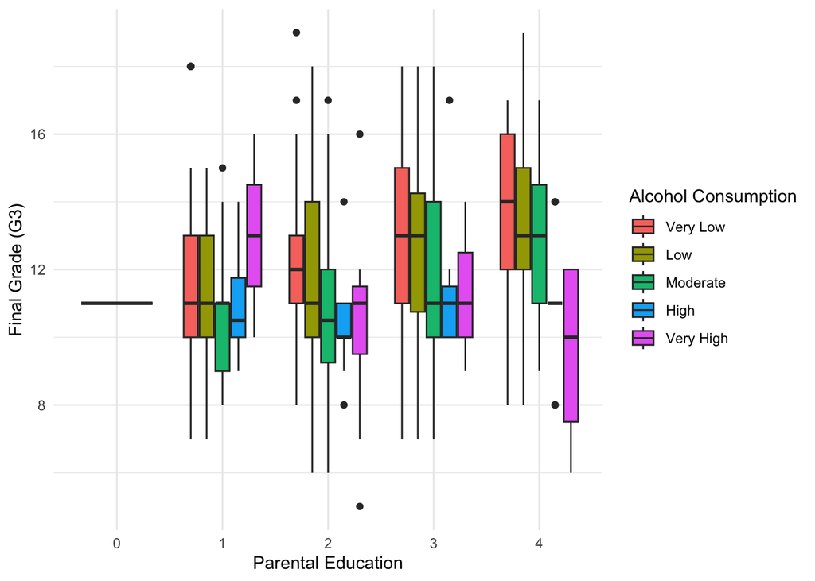

```r
# Define custom labels for alcohol consumption levels
alc_labels <- c("Very Low", "Low", "Moderate", "High", "Very High")

# Generate boxplots with automatic colors and custom labels
ggplot(studentData, aes(x = factor(parent_edu), y = G3, fill = factor(alc))) +
  geom_boxplot() +
  labs(x = "Parental Education", y = "Final Grade (G3)", fill = "Alcohol Consumption") +
  scale_fill_discrete(name = "Alcohol Consumption", labels = alc_labels) + # Specify custom labels
  theme_minimal()
```

# Statistical Analysis and Interpretation

## T-test to compare two sex groups

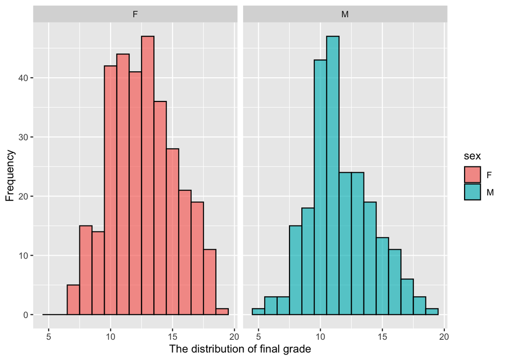

```r
studentData$sex <- ifelse(studentData$sex == 0, "M", "F")

#Check for assumptions
ggplot(data = studentData, aes(x = G3, fill = sex)) +
  geom_histogram(color = "black", alpha = 0.7, binwidth = 1) +
  facet_wrap(~sex) +
  labs(x = "The distribution of final grade", y = "Frequency") +
   theme(plot.title = element_text(hjust = 0.5))
```

```r
# t.test
t.test(data = studentData, G3 ~ sex)
```

```
##
##  Welch Two Sample t-test
##
## data:  G3 by sex
## t = 4.4278, df = 504.99, p-value = 1.168e-05
## alternative hypothesis: true difference in means between group F and group M is not equal to 0
## 95 percent confidence interval:
##  0.5529005 1.4349142
## sample estimates:
## mean in group F mean in group M
##        12.61728        11.62338
```

## Multiple linear regression to predict the final grades

We perform a multiple linear regression model to find the relationship among gender, family background, alcohol consumption, and students’ final grade. In this model, gender is represented by the dummy variable “sex” which takes a value of 0 for Male and 1 for Female. Family background is represented by the ordinal variable “parent_edu” that shows the 5 education levels of students’ parents (0-4). Alcohol consumption is represented by the ordinal variable “alc” with 5 different consumption levels (1-5).

```r
# Change sex to numeric variables (M = 0, F = 1)
studentData$sex <- ifelse(studentData$sex == "M", 0, 1)
# Handle ordinal variables by defining levels and labels for ordinal variables
studentData$alc <- factor(studentData$alc, levels = 1:5, labels = c("Very Low", "Low", "Moderate", "High", "Very High"))
studentData$parent_edu <- factor(studentData$parent_edu, levels = 0:4, labels = c("No education", "Primary", "5th-9th Grade", "Secondary", "Higher"))

# Fit the linear regression model
model <- lm(G3 ~ sex + alc + parent_edu, data = studentData)

# Display summary of the model
summary(model)
```

```
##
## Call:
## lm(formula = G3 ~ sex + alc + parent_edu, data = studentData)
##
## Residuals:
##     Min      1Q  Median      3Q     Max
## -6.3642 -1.6635 -0.1338  1.5722  6.8662
##
## Coefficients:
##                         Estimate Std. Error t value Pr(>|t|)
## (Intercept)              10.0922     2.5061   4.027 6.45e-05 ***
## sex                       0.9078     0.2293   3.958 8.54e-05 ***
## alcLow                   -0.3862     0.2481  -1.557  0.12006
## alcModerate              -0.8564     0.3205  -2.672  0.00777 **
## alcHigh                  -1.3510     0.4813  -2.807  0.00518 **
## alcVery High             -1.3909     0.6064  -2.293  0.02220 *
## parent_eduPrimary         1.1054     2.5137   0.440  0.66030
## parent_edu5th-9th Grade   1.4278     2.5070   0.570  0.56924
## parent_eduSecondary       2.3642     2.5093   0.942  0.34651
## parent_eduHigher          3.0143     2.5104   1.201  0.23038
## ---
## Signif. codes:  0 '***' 0.001 '**' 0.01 '*' 0.05 '.' 0.1 ' ' 1
##
## Residual standard error: 2.496 on 545 degrees of freedom
## Multiple R-squared:  0.1368, Adjusted R-squared:  0.1225
## F-statistic: 9.595 on 9 and 545 DF,  p-value: 1.189e-13
```

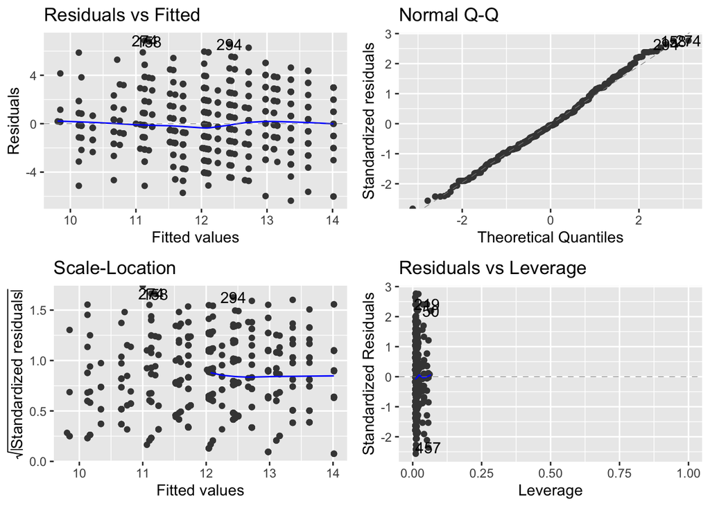

```r
# Check for assumptions
autoplot(model)
```